# Bike Share Trips Prediction in Chicago

### 1. Purpose of our prediction

Riding bike is an affordable and environmental-friendly approach to get around. As a bike share system in Chicago, Divvy is operating 580 bike stations in the city. However, we discover that this bike share system needs improvement. Sometimes stations have either no enough bikes to use or no enough docks for riders to park their bikes. Therefore, we decided to build a model predicting hourly bike departures for each bike stations, and create a product for bike balancing that will provide more user-friendly and smarter usages for bike users.

There is an existing Divvy app which tells users the location of bike stations, how many bikes and docks available, and where to stop your bike. However, it is not able to tell you if there will be bikes available when you arrive at the station, how long to wait for a bike from an empty station, and if there will be docks available when you arrive at your destination. Divvy can be smarter.

### 2. Data source

There are 580 bike stations in Chicago. In our prediction, we decide to choose 144 bike stations as our sample. The bike stations we select are located in four communities around the center city including Loop, Near West Side, Near South Side, and Near North Side. By selecting bike stations in different types of communities we can increase the variety of our samples and make sure that our model is accurate and generalizable in different areas.

Our dependent variable is departures for each selected bike station in every hour from August 1st to 7th in 2015, including 24192 samples. The independent variables consist of three categories: time variables, spatial variables, and social and economic characteristics for each census tract. Data sources come from Chicago Data Portal and ACS 5 years estimate from US Census Bureau.

Time variables: The total departure for each hour in Chicago Daily weather: including temperature, humidity, rain intensity, total rain, wind speed, barometric pressure, solar radiation Hourly departures for the selected bike stations in the last week Hourly arrivals for the selected bike stations in the last week Time lag departures 1: Departures one hour ago Time lag departures 2: Departures two hours ago

Spatial variables: Distance to bike lane Distance to bus stations Length of bike lane in each census tract Bike lane density in each census tract Average distance to the nearest three landmarks Distance to parks ? dis_hipr ? Rack density (in the buffer of each station) Distance to metro stations Street density in each census tract

Social and economic characteristics for census tracts: Median household income Number of households ? bachelor _s & bachelor_p Total population Percent of population commute by car Mean time to work Percent of population below poverty line Male population Median age Median household value Median gross rent for tracts

### 4. Prediction model

We build and compare two different models for our prediction. In the first model, we use all the variables mentioned above, while in the second model, we exclude all the spatial and social-economic characteristics of census tracts, and replace them with the station names of each bike station. Then we run the regressions and the 10-fold cross validation. By comparing the two models, we discover that although the r square of the first model is a little bit lower, the mean absolute error is also lower as well. Thus, in this case, we decide that the first model is better for the prediction, since we want our model to be more generalizable.

| R square | MAE | Regression |
| --- | --- | --- |
| 0.6910018 | 1.721398 | regression 1 |
| 0.6941898 | 1.738036 | regression 2 |

The result shows that among all the variables, the five most significant variables are all time variables, including the hourly departures and arrivals of the same day in the last week, the departure an hour ago, rain intensity of that day, and the number of day.

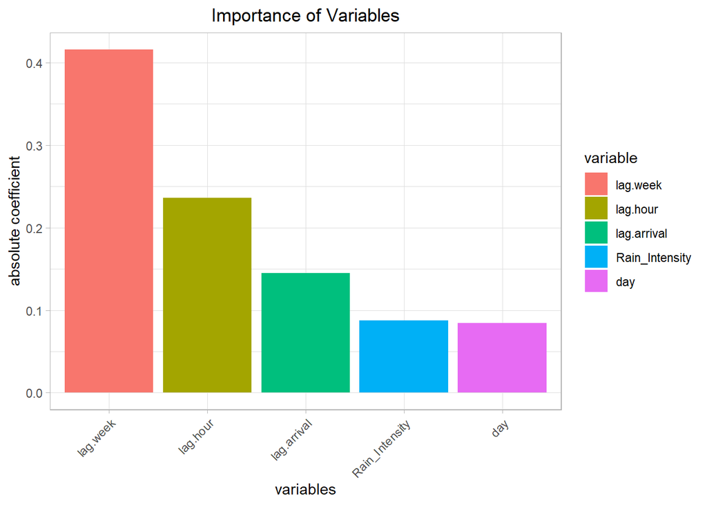

### 5. Model validation

To test if our model is generalizable for both the weekday and weekend, we use this model to predict for one weekend, Aug.8th, and one weekday, Aug 10th.

For the training set, some of the time variables are based on real-time information, for example, the weather of that day. However, we are not able to know the weather when we are predicting for someday in the future. So for the test set, we assume that these variables are the same as the same day of last week: (1) Weather of the predicting day (2) The hourly departure of the whole city in the predicting day (3) The time lag departures: departures one hour and two hours ago

For the predicting days, we calculate the mean absolute percent error (MAPE) for each hour to test if our model is doing well in different time of one day: MAPE = mean absolute error of all stations/total departure of all stations

The result shows that the percent of error is larger at night for both the weekday and the weekend, but it is much lower and more stable during the day time, which means that our model is doing well at hours with more departures. This is the outcome we want, since typically, more people use bikes in daytime, and fewer people use bikes at midnight.

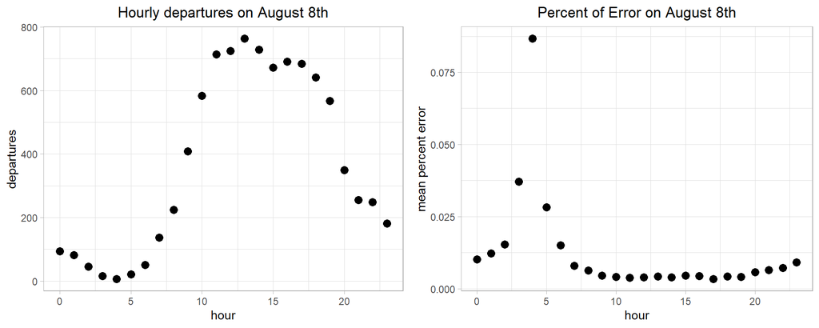

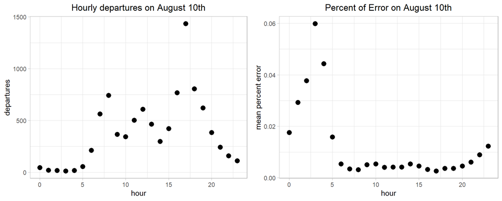

We also map the MAPE for each station to see if our model is doing well for all stations: MAPE = mean absolute error of all hours in one day/total departure of all hours in one day

The result shows that the percent of error is larger for stations with less departures, and lower for stations with more departures. This also means that our model is doing better at stations with more departures.

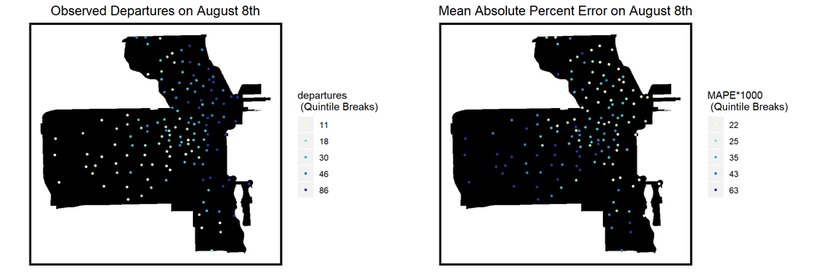

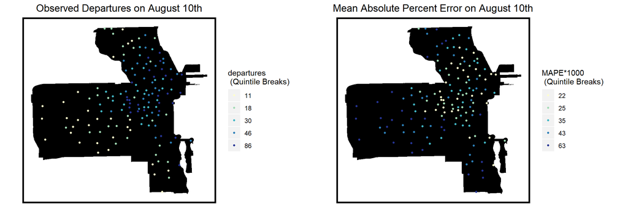

In conclusion, our model is valid and useful in the real world, since it is comparatively doing well at predicting hours and stations with more departures, and normally more frequently used stations during busy time are more in need of bike rebalancing.

### 6. Usage of the model

In this case, we are predicting the departures for each hour. This model can also be used to predict the bike arrivals. By combining the prediction of departures and arrivals, we will know how many bikes and docks available in the next few hours, and therefore can provide more information to the bike users.

Imagine there is an app which can tell you how many bikes available in different stations within the next few hours, how the available bikes will change in the future, how long should I wait to get a bike, and what is the most time efficient trip. This new app we are designing is called Divvy plus, which will create smarter, more time efficient divvy trips for all the bike users. When you open our Divvy plus, you will see that the bike stations are categorized as three different colors. The red station means that there is currently no bike available, the yellow station means that there are bikes available now, but there will be no bike in the following hour, and the green station means that there is and will be bikes available in the following hour.

This app is also able to balance the usage of bikes in the future. If users want to use a bike, the app will search for the nearest available stations. If the nearest station is currently no bike available, it will calculate your wait time for the next available bike. It will also offer an alternative choice by searching for the nearest bike station with bikes currently available and calculate the cost of time to get there.

What if all the bike stations around you will not be available in the next hour? Our Divvy plus will then calculate the average waiting time for you. It will also provide a list of all the wait time of your nearby stations, and calculate the distances and cost of time to get to the station, so that you can choose your trip between the shortest walk and the shortest cost of time.

What if you arrive at your destination, and find that there is no available dock for you to park your bike? When typing in your destination in our app, it will search for the nearest bike station from your destination with docks available, so that you will know where you can park your bike at the end of the trip. It will also calculate the total cost of time of your trip and provide different trip options, so that you are able to plan for your trip in advance.

### 7. Improvement

Our model and app still need improvement. We can include more samples and more historical data in our model. If we include departures from the last few weeks and months, our model will be more accurate and generalizable. We can also let the users to report error on our app when we fail to predict departure for some stations, and include that error report as a variable in our model. In this way we can improve the accuracy of our model by engaging our users.